# Übungsaufgabe 5

Fabio Votta

30.November 2017

**Datenaufbereitung**

```r
*Alter.
compute alter0= v84-18.
variable labels alter0 "Alter mit 18 als Nullpunkt".

frequencies alter0.


*Bildung.
Recode v86 (1=0) (2=1) (3=2) (4=3) (5=4) (else=SYSMIS) into bildung_rec.
variable labels bildung_rec "Abschluss umkodiert".
value labels bildung_rec 0"Kein Schulabschluss" 1"Hauptschule" 2"Realschule" 3"Fachhochschulreife" 4"Abi".

frequencies bildung_rec.


*Geschlecht.
Recode v81 (2=0) (1=1) (else=copy) into geschl_rec.
variable labels geschl_rec "Geschlecht mit w=0".
value labels geschl_rec 0"weiblich" 1"mÃ¤nnlich".

frequencies geschl_rec.


*Einkommen.
COMPUTE einkommen = v420.

frequencies einkommen.
```

*Erstellen Sie eine Regression von Einkommen auf Bildung, Geschlecht und Alter sowie der Dummyvariablen Zugang zu tertiärer Bildung (bild_tert), die null kodiert ist, wenn der betreffende Befragte einen niedrigeren Schulabschluss als Fachhochschulreife hat und eins, wenn Umgekehrtes der Fall ist. Hinzu kommen die Interaktionsvariablen zwischen Geschlecht und Alter (gesch_alter) sowie zwischen Alter und Zugang zu tertiärer Bildung (alt_tert).*

- `0` OHNE ABSCHLUSS
- `1` VOLKS-,HAUPTSCHULE
- `2` MITTLERE REIFE
- `3` FACHHOCHSCHULREIFE
- `4` HOCHSCHULREIFE

```r
*Bildung Tertiär dummy.
COMPUTE bild_tert = bildung_rec > 2.
*Alter und Geschlecht Interaktion.
COMPUTE gesch_alter = alter0 * geschl_rec .
*Alter und tertiäre Bildung Interaktion.
COMPUTE alt_tert = alter0 * bild_tert .


REGRESSION
  /DEPENDENT einkommen
  /METHOD=ENTER bildung_rec geschl_rec alter0 bild_tert gesch_alter alt_tert.
```

### Aufgabe 1a

*Berechnen Sie das Konfidenzintervall für die Variablen bild_tert und Alter mittels der Koeffizienten und interpretieren Sie diese.*

$$KI_{95} = b \pm t_{df} \times SE_b$$

Für $df > 120$ und $95\%$ Signifikanzniveau ist der kritische Wert $t = 1.96$

Für $df > 120$ und $99\%$ Signifikanzniveau ist der kritische Wert $t = 2.58$

Koeffizienten<sup>a</sup>Koeffizienten, Tabelle, 2 Stufen von Spaltenüberschriften und 2 Stufen von Zeilenüberschriften, Tabelle mit 7 Spalten und 11 Zeilen

| Modell |  | Nicht standardisierte Koeffizienten |  | Standardisierte Koeffizienten | T | Sig. |  |  |
| --- | --- | --- | --- | --- | --- | --- | --- | --- |
|  |  | RegressionskoeffizientB | Standardfehler | Beta |  |  |  |  |
| 1 | (Konstante) | 6,884 | ,411 |  |  |  | 16,736 | ,000 |
|  | Abschluss umkodiert | 1,062 | ,161 | ,258 | 6,614 | ,000 |  |  |
|  | Geschlecht mit w=0 | 2,549 | ,334 | ,257 | 7,640 | ,000 |  |  |
|  | Alter mit 18 als Nullpunkt | -,002 | ,008 | -,007 | -,260 | ,795 |  |  |
|  | bild_tert | -1,836 | ,468 | -,178 | -3,920 | ,000 |  |  |
|  | gesch_alter | ,029 | ,009 | ,120 | 3,172 | ,002 |  |  |
|  | alt_tert | ,075 | ,010 | ,248 | 7,542 | ,000 |  |  |

a. Abhängige Variable: einkommen

- 95% Konfidenzintervall für `bild_tert`

```r
-1.836236 - 1.96 * 0.468472
```

[1] -2.754441

```r
-1.836236 + 1.96 * 0.468472
```

[1] -0.9180309

- 95% Konfidenzintervall für `alter0`

```r
-0.001996 - 1.96 * 0.007663
```

[1] -0.01701548

```r
-0.001996 + 1.96 * 0.007663
```

[1] 0.01302348

### Aufgabe 1b

*Testen Sie das Gesamtmodell auf Linearität.*

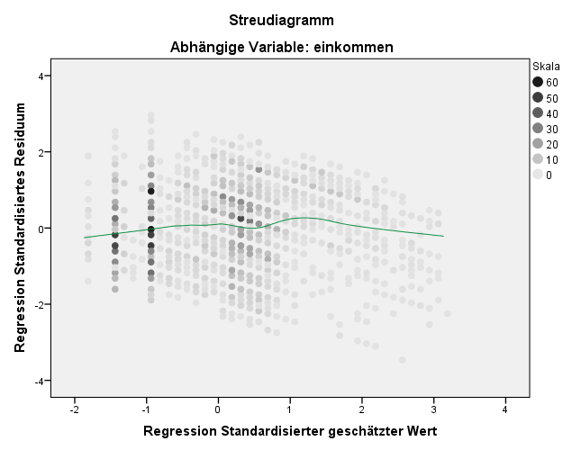

```r
REGRESSION
  /DEPENDENT einkommen
  /METHOD=ENTER bildung_rec geschl_rec alter0 bild_tert gesch_alter alt_tert
  /SCATTERPLOT=(*ZRESID , *ZPRED).
```

Durch eine visuelle Untersuchung der Residuen und der vorhergesagten Werte und einer Loess-Kurve kann vermutet werden, dass ein nicht-linearer Zusammenhang besteht. Diese Nicht-Linearität kommt höchstwahrscheinlich von dem quadratischen Effekt von Alter.

## Aufgabe 2

*Was ist unter Multikollinearität zu verstehen, warum ist es ein Problem, wenn diese in einer Modellschätzung vorliegt und wie kann das Vorliegen derselben diagnostiziert werden?*

Eine Multikollinerarität liegt vor, wenn unabhängige Variablen untereinander korrelieren. Problematisch ist das, weil bei einer zu hohen Korrelation zwischen den unabhängigen Variablen die Effekte nicht mehr auf einzelne unabhängige Variablen zurückzuführen sind und die b-Koeffizienten sowie Standardfehler stark verzerrt werden. Ob Multikollinearität vorliegt, kann man zum Beispiel durch das Erstellen einer Korrelationsmatrix, in welcher alle bivariaten Zusammenhänge aller unabhängigen Variablen berechnet werden, überprüfen. Eine weitere Möglichkeit ist die Berechnung der Toleranzwerte (oder VIF-Werte) für die X-Variablen. So wird angegeben, wie hoch die eigenständige Erklärungskraft einer X-Variable ist, also wie viel Anteil an Varianz sie selbst erklären kann. Sinkt dieser Wert unter 0,2 (über 5 VIF), hat die Variable wenig Eigenerklärungskraft.

## Aufgabe 3

*Wie ausgeprägt ist die Multikollinearität im Regressionsmodell von Aufgabe 1? Welche Gründe (inhaltliche) lassen sich für die Multikollinearität identifizieren?*

```r
REGRESSION
  /STATISTICS COEFF OUTS CI(95) R BCOV TOL
  /DEPENDENT einkommen
  /METHOD=ENTER bildung_rec geschl_rec alter0 bild_tert gesch_alter alt_tert.
```

Koeffizienten<sup>a</sup>Koeffizienten, Tabelle, 2 Stufen von Spaltenüberschriften und 2 Stufen von Zeilenüberschriften, Tabelle mit 11 Spalten und 11 Zeilen

| Modell |  | Nicht standardisierte Koeffizienten |  | Standardisierte Koeffizienten | T | Sig. | 95,0% Konfidenzintervalle für B |  | Kollinearitätsstatistik |  |
| --- | --- | --- | --- | --- | --- | --- | --- | --- | --- | --- |
|  |  | RegressionskoeffizientB | Standardfehler | Beta |  |  | Untergrenze | Obergrenze | Toleranz | VIF |
| 1 | (Konstante) | 6,884 | ,411 |  | 16,736 | ,000 | 6,078 | 7,691 |  |  |
|  | Abschluss umkodiert | 1,062 | ,161 | ,258 | 6,614 | ,000 | ,747 | 1,377 | ,167 | 5,972 |
|  | Geschlecht mit w=0 | 2,549 | ,334 | ,257 | 7,640 | ,000 | 1,895 | 3,203 | ,224 | 4,457 |
|  | Alter mit 18 als Nullpunkt | -,002 | ,008 | -,007 | -,260 | ,795 | -,017 | ,013 | ,355 | 2,813 |
|  | bild_tert | -1,836 | ,468 | -,178 | -3,920 | ,000 | -2,755 | -,918 | ,123 | 8,104 |
|  | gesch_alter | ,029 | ,009 | ,120 | 3,172 | ,002 | ,011 | ,047 | ,179 | 5,583 |
|  | alt_tert | ,075 | ,010 | ,248 | 7,542 | ,000 | ,056 | ,095 | ,236 | 4,234 |

a. Abhängige Variable: einkommen

Die VIF-Werte sollten den Grenzwert von 5 nicht überschreiten (bzw. Toleranzwerte über 0,2). Dies tun allerdings sowohl die eigentliche Bildungs-Variable, als auch die Dummy-Bildungs-Variable, als auch die Interaktionsvariable von Geschlecht und Alter.

Die Multikollinearität kann in diesem Modell ganz klar darauf zurück geführt werden, dass die Dummy-Variable `bild_tert` sich mit der Bildungsvariable informationstechnisch überschneidet sowie Interaktionsvariablen mit aufgenommen wurden.